# Nachnutzung und Analyse unterrichtsbezogener Videodaten

02. Juni 2022

## Punkte aus der Ausschreibung

1. “eigenständige Forschung mit Videodaten”
2. “Weiterentwicklung der Methodik”
3. “Infrastruktur für Nachnutzung und Analyse unterrichtsbezogener Videodaten”

## Unterrichtsvideos

## Theoretische Einordnung

Nutzung von Video zur Erforschung…

von Unterrichtspraxis  
*(Video als Datenquelle)*

der Entwicklung  
von Professionalität  
*(Video als Lernressource)*

## Theoretische Einordnung

Nutzung von Video zur Erforschung…

von Unterrichtspraxis  
*(Video als Datenquelle)*

der Entwicklung  
von Professionalität  
*(Video als Lernressource)*

## Theoretische Einordnung

Nutzung von Video zur Erforschung…

von Unterrichtspraxis  
*(Video als Datenquelle)*

der Entwicklung  
von Professionalität  
*(Video als Lernressource)*

- Reflexion über Unterrichtsfälle als Chance der Entwicklung von Professionalität (Schneider & Cramer, 2020)
- über prominente Professionalisierungstheorien hinweg (Baumert & Kunter, 2006; Helsper, 2004; Terhart, 2000)

## Unterrichtsvideos

### für die professionelle Entwicklung von Lehrpersonen (1)

**(Kleinknecht & Schneider, 2013)**

Lehrpersonen  
Vergleich schriftlicher Analysen bzgl. **eigener** vs. **fremder** Videos  
Analyse von Unterricht, emotionale und motivationale Äußerungen

## Unterrichtsvideos

### für die professionelle Entwicklung von Lehrpersonen (1)

**(Kleinknecht & Schneider, 2013)**

Lehrpersonen  
Vergleich schriftlicher Analysen bzgl. **eigener** vs. **fremder** Videos  
Analyse von Unterricht, emotionale und motivationale Äußerungen

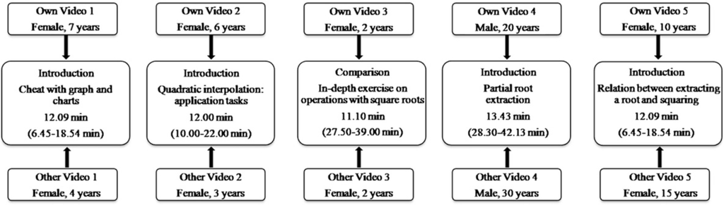

## Unterrichtsvideos

### für die professionelle Entwicklung von Lehrpersonen (2)

**(Schneider, Kleinknecht, et al., 2021; Schneider, 2016; Schneider, Bohl, et al., 2016)**

Lehramtsstudierende  
Vergleich **Video-** vs. **Textfälle**, **direkte** Instruktion vs. **problemorientiertes** Lernen  
Analyse von Unterricht

## Unterrichtsvideos

### für die professionelle Entwicklung von Lehrpersonen (2)

**(Schneider, Kleinknecht, et al., 2021; Schneider, 2016; Schneider, Bohl, et al., 2016)**

Lehramtsstudierende  
Vergleich **Video-** vs. **Textfälle**, **direkte** Instruktion vs. **problemorientiertes** Lernen  
Analyse von Unterricht

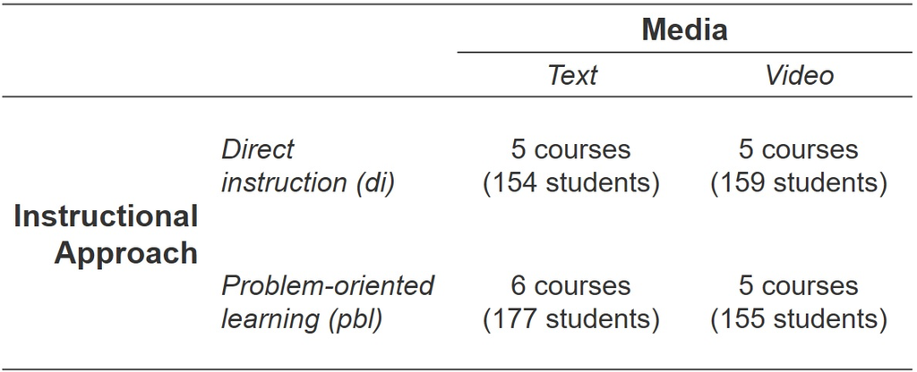

## Unterrichtsvideos

### für die professionelle Entwicklung von Lehrpersonen (3)

**(Schneider & Petko, 2021)**

- Core Practices als pragmatistische Perspektive auf Professionalität
- Professionalisierungprozesse (Repräsentation, Dekomposition, Approximation)
- These: digitale Ressourcen ermöglichen Professionalisierung in besonderem Maße

## Unterrichtsvideos

### für die professionelle Entwicklung von Lehrpersonen (3)

**(Schneider & Petko, 2021)**

- Core Practices als pragmatistische Perspektive auf Professionalität
- Professionalisierungprozesse (Repräsentation, Dekomposition, Approximation)
- These: digitale Ressourcen ermöglichen Professionalisierung in besonderem Maße

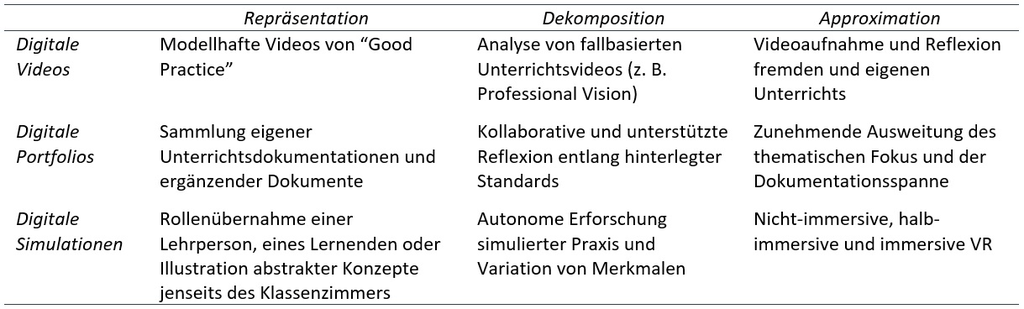

## Unterrichtsvideos

### im Hinblick auf das Themengebiet der Stelle

Nutzung von Video zur Erforschung…

von Unterrichtspraxis  
*(Video als Datenquelle)*

der Entwicklung  
von Professionalität  
*(Video als Lernressource)*

## Unterrichtsvideos

### im Hinblick auf das Themengebiet der Stelle

Nutzung von Video zur Erforschung…

von Unterrichtspraxis  
*(Video als Datenquelle)*

der Entwicklung  
von Professionalität  
*(Video als Lernressource)*

**Einblicke und breite Erfahrung, …**

1. welche Aspekte von Unterricht sich überhaupt *beobachten* und *beforschen* lassen
2. welche *Kontextinformationen* zur Erkenntnisgenese aus Videodaten benötigt werden
3. wie Unterrichtsvideos *entstehen*, was sie *erfassen* und was sie *nicht erfassen*

## Vielen Dank

**Jürgen Schneider**  
juergen.schneider@uni-tuebingen.de

## Forschungsmethodik

## Forschungsmethodik

### Crowdsourced Data Analysis

**(Breznau, Rinke, Wuttke, Adem, et al., 2021; Breznau, Rinke, Wuttke, Nguyen, et al., 2021)**

Crowdsourced (computational) Replication und Extension  
von Brady und Finnigan (2014)  
Computational Replication der Ergebnisse  
Eigene Auswertung derselben Hypothese

## Forschungsmethodik

### Crowdsourced Data Analysis

**(Breznau, Rinke, Wuttke, Adem, et al., 2021; Breznau, Rinke, Wuttke, Nguyen, et al., 2021)**

Crowdsourced (computational) Replication und Extension  
von Brady und Finnigan (2014)  
Computational Replication der Ergebnisse  
Eigene Auswertung derselben Hypothese

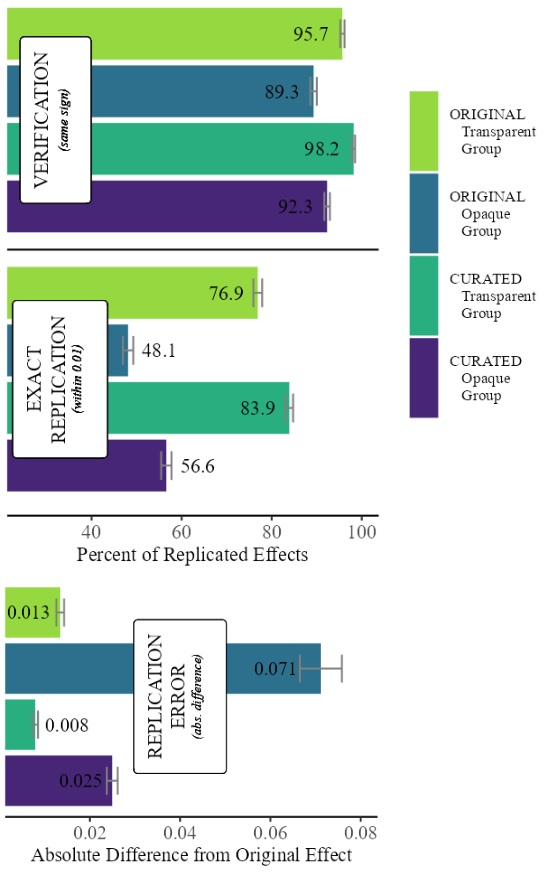

## Forschungsmethodik

### Crowdsourced Data Analysis

**(Breznau, Rinke, Wuttke, Adem, et al., 2021; Breznau, Rinke, Wuttke, Nguyen, et al., 2021)**

Crowdsourced (computational) Replication und Extension  
von Brady und Finnigan (2014)  
Computational Replication der Ergebnisse  
Eigene Auswertung derselben Hypothese

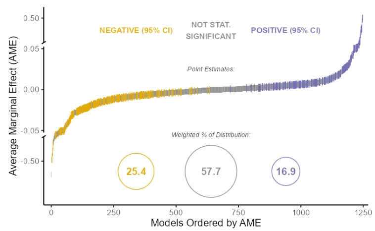

## Forschungsmethodik

### Standards

**(Schneider, Backfisch, et al., 2022)**

Präregistrierung von Metaanalysen & Systematischen Reviews  
“make it easy”: Datenanalysen, Multimedia, Multi-File, …  
RMarkdown Package *{preregRS}*

[Link zum Beispiel](https://raw.githack.com/j-5chneider/preregRS-jupyter/main/preregRS_example.html)

## Forschungsmethodik

### Standards

**(Schneider, Backfisch, et al., 2022)**

Präregistrierung von Metaanalysen & Systematischen Reviews  
“make it easy”: Datenanalysen, Multimedia, Multi-File, …  
RMarkdown Package *{preregRS}*

[Link zum Beispiel](https://raw.githack.com/j-5chneider/preregRS-jupyter/main/preregRS_example.html)

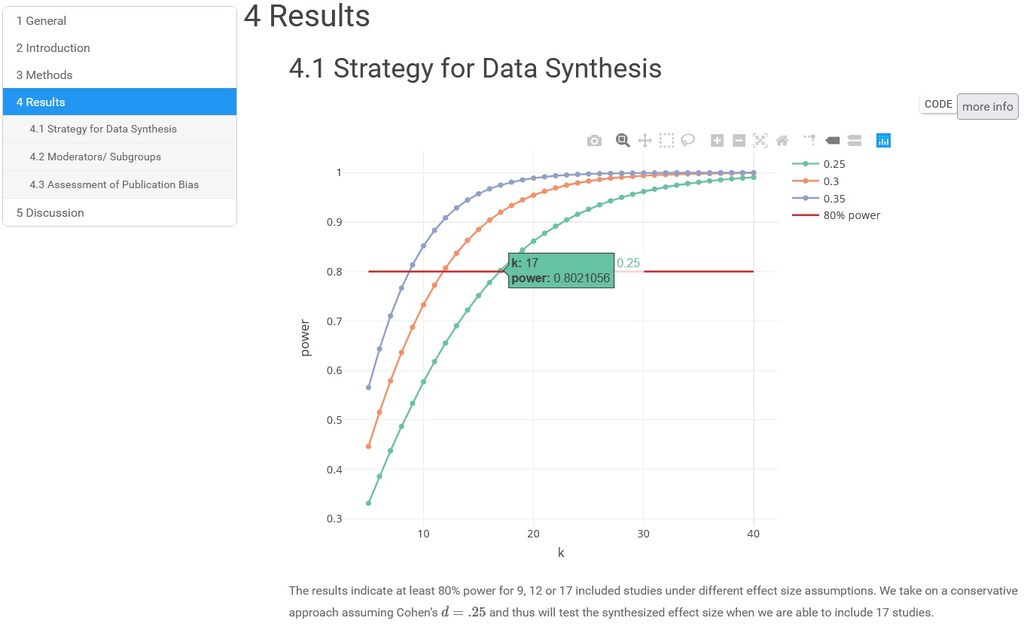

## Open Science

## Open Science

**(Schneider, Rosman, et al., 2021)**:  
Einfluss von *Open Science Badges* auf *Vertrauen* in Wissenschaftler*innen

**(Schneider, 2022)**:  
*Anwendbarkeit* von Open Science Praktiken in unterschiedlichen Disziplinen & Forschungsparadigmen

**(Lasser et al., 2022)**:  
*Mapping Review* der Literatur zu Open Science

Baumert, J., & Kunter, M. (2006). Stichwort: Professionelle Kompetenz von Lehrkräften. *Zeitschrift Für Erziehungswissenschaft*, *9*(4), 469–520. https://doi.org/10.1007/s11618-006-0165-2

Breznau, N., Rinke, E. M., Wuttke, A., Adem, M., Adriaans, J., Alvarez-Benjumea, A., Andersen, H. K., Auer, D., Azevedo, F., Bahnsen, O., Balzer, D., Bauer, G., Bauer, P., Baumann, M., Baute, S., Benoit, V., Bernauer, J., Berning, C., Berthold, A., … Nguyen, H. (2021). *Observing Many Researchers using the Same Data and Hypothesis Reveals a Hidden Universe of Data Analysis* [Preprint]. MetaArXiv. https://doi.org/10.31222/osf.io/cd5j9

Breznau, N., Rinke, E. M., Wuttke, A., Nguyen, H. H. V., Adem, M., Adriaans, J., Akdeniz, E., Alvarez-Benjumea, A., Andersen, H. K., Auer, D., Azevedo, F., Bahnsen, O., Bai, L., Balzer, D., Bauer, G., Bauer, P., Baumann, M., Baute, S., Benoit, V., … Żółtak, T. (2021). *How Many Replicators Does It Take to Achieve Reliability? Investigating Researcher Variability in a Crowdsourced Replication* [Preprint]. SocArXiv. https://doi.org/10.31235/osf.io/j7qta

Helsper, W. (2004). Antinomien, Widersprüche, Paradoxien: Lehrerarbeit- ein unmögliches Geschäft? Eine strukturtheoretisch- rekonstruktive Perspektive auf das Lehrerhandeln. In B. Koch-Priewe, F.-U. Kolbe, & J. Wildt (Eds.), *Grundlagenforschung und mikrodidaktische Reformansätze zur Lehrerbildung* (pp. 49–98). Klinkhardt.

Kleinknecht, M., & Schneider, J. (2013). What do teachers think and feel when analyzing videos of themselves and other teachers teaching? *Teaching and Teacher Education*, *33*, 13–23. https://doi.org/10.1016/j.tate.2013.02.002

Lasser, J., Schneider, J., Lösch, T., Röwert, R., Heck, T., Bluemel, C., Neufend, M., Steinhardt, I., & Skupien, S. (2022). *MapOSR - A mapping review dataset of empirical studies on Open Science* (11:535). F1000Research. https://doi.org/10.12688/f1000research.121665.1

Schneider, J. (2016). *Lehramtsstudierende analysieren Praxis: Ein Vergleich der Effekte unterschiedlicher fallbasierter Lehr-Lern-Arrangements* [Thesis]. https://doi.org/10.15496/publikation-13255

Schneider, J. (2022). Applicability of open science practices to completed research projects from different disciplines and research paradigms. *F1000Research*, *11*, 408. https://doi.org/10.12688/f1000research.111383.1

Schneider, J., Backfisch, I., & Lachner, A. (2022). Facilitating Open Science Practices for Research Syntheses: PreregRS Guides Preregistration. *Research Synthesis Methods*, *13*(2), 284–289. https://doi.org/10.1002/jrsm.1540

Schneider, J., Bohl, T., Kleinknecht, M., Rehm, M., Kuntze, S., & Syring, M. (2016). Unterricht analysieren und reflektieren mit unterschiedlichen Fallmedien: Ist Video wirklich besser als Text? *Unterrichtswissenschaft*, *44*(4), 474–491.

Schneider, J., & Cramer, C. (2020). Relationierung von Theorie und Praxis: Was bedeutet dieses Konzept für die Begleitung von Praktika in der Lehrerinnen- und Lehrerbildung? In K. Rheinländer & D. Scholl (Eds.), *Verlängerte Praxisphasen in der universitären Lehrerbildung: Spannungsfelder zwischen Theorie, Praxis und der Bestimmung von Professionalisierung* (pp. 23–38). Klinkhardt.

Schneider, J., Kleinknecht, M., Bohl, T., Kuntze, S., Rehm, M., & Syring, M. (2021). *Using authentic representations of practice in teacher education: Do direct instructional and problem-based approaches really produce different effects? [Manuscript submitted for publication]*.

Schneider, J., & Petko, D. (2021). *Digitale Möglichkeiten zur Förderung von Core Practices in der Lehrpersonenbildung [Manuscript submitted for publication]*.

Schneider, J., Rosman, T., Kelava, A., & Merk, S. (2021). *Do Open Science Badges Increase Trust in Scientists among Student Teachers, Scientists, and the Public? [Manuscript submitted for publication]*. https://doi.org/10.31234/osf.io/43ec2

Terhart, E. (2000). Lehrerbildung und Professionalität. In J. Bastian, W. Helsper, S. Reh, & C. Schelle (Eds.), *Professionalisierung im Lehrerberuf. Von der Kritik der Lehrerrolle zur pädagogischen Professionalität* (pp. 73–85). Leske u. Budrich.

**Credit:**

Icons by Font Awesome CC BY 4.0  
Title page photo by [Taylor Wilcox](https://unsplash.com/@taypaigey?utm_source=unsplash&utm_medium=referral&utm_content=creditCopyText) on [Unsplash](https://unsplash.com/?utm_source=unsplash&utm_medium=referral&utm_content=creditCopyText)